# Statistics2, lab week 2: repeated measures ANOVA

Robert van Timmeren s4535553

April 16th, 2021

# 1 Load data and libraries

The data is given in a format similar to that of file dialect_change_1.csv in the lecture and we need it in a format similar to dialect_change2.csv.

We load the data and create two factor variables, one for the groups and another one for the subjects.

```r
library(car)
library(ez)
RT <- c(461,245,846,976,567,318,567,689,432,658,478,571,578,769,389,518,
        789,368,901,948,890,431,489,543,937,698,498,389,486,777,446,324,
        478,336,753,653,639,302,371,782,480,352,447,434,307,543,787,349,
        646,564,827,824,987,357,598,334,789,599,955,578,778,659,680,448)
mygroups = c("SR_ANP","OR_ANP","SR_INP","OR_INP")

# create a sequence of numbers from 1 to 16. Hint: use function seq()
mysubjects = seq(1, 16)

# each group is repeated 16 times
# vector subjects has less elements (16) than RT (64), therefore it will be repeated 4 times
mydata <- data.frame(RT, rep(mygroups, each=16), mysubjects)

colnames(mydata) <- c("RT", "Group", "Subj") # rename to more meaningful names

# we need Subj to be a factor for the analyses below, and it wasn't by default. You can check with str(mydata). Make it a factor using function as.factor()
mydata$Subj <- as.factor(mydata$Subj)

# Groups also needs to be a factor
mydata$Group <- as.factor(mydata$Group)

# Check if data is now correct
str(mydata)
```

```
## 'data.frame':    64 obs. of  3 variables:
##  $ RT   : num  461 245 846 976 567 318 567 689 432 658 ...
##  $ Group: Factor w/ 4 levels "OR_ANP","OR_INP",..: 3 3 3 3 3 3 3 3 3 3 ...
##  $ Subj : Factor w/ 16 levels "1","2","3","4",..: 1 2 3 4 5 6 7 8 9 10 ...
```

# 2 Boxplots

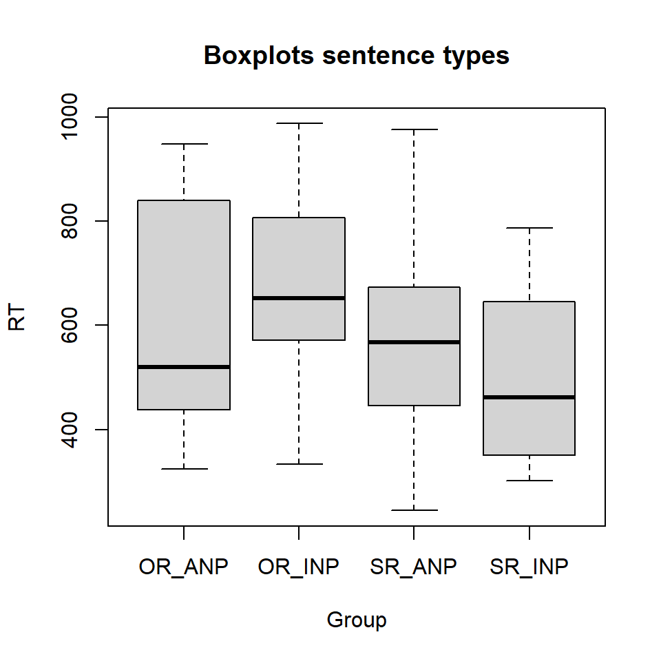

```r
# Boxplots of four sentence types.
boxplot(mydata$RT ~ mydata$Group, xlab = "Group", ylab = "RT", main = "Boxplots sentence types")
```

# 3 Hypotheses

$H_0$: μ<sub>SR_ANP</sub> = μ<sub>OR_ANP</sub> = μ<sub>SR_INP</sub> = μ<sub>OR_INP</sub>

$H_0$: not all of the μ<sub>i</sub> are equal

# 4 Normality

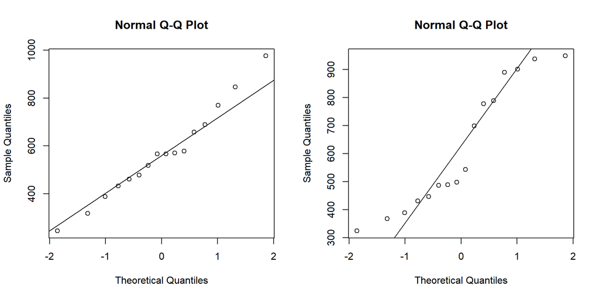

```r
par(mfrow=c(1,2))
# Creating q-q plots for all four groups
# SR_ANP
qqnorm(mydata[mydata$Group == 'SR_ANP', ]$RT)
qqline(mydata[mydata$Group == 'SR_ANP', ]$RT)

# OR_ANP
qqnorm(mydata[mydata$Group == 'OR_ANP', ]$RT)
qqline(mydata[mydata$Group == 'OR_ANP', ]$RT)
```

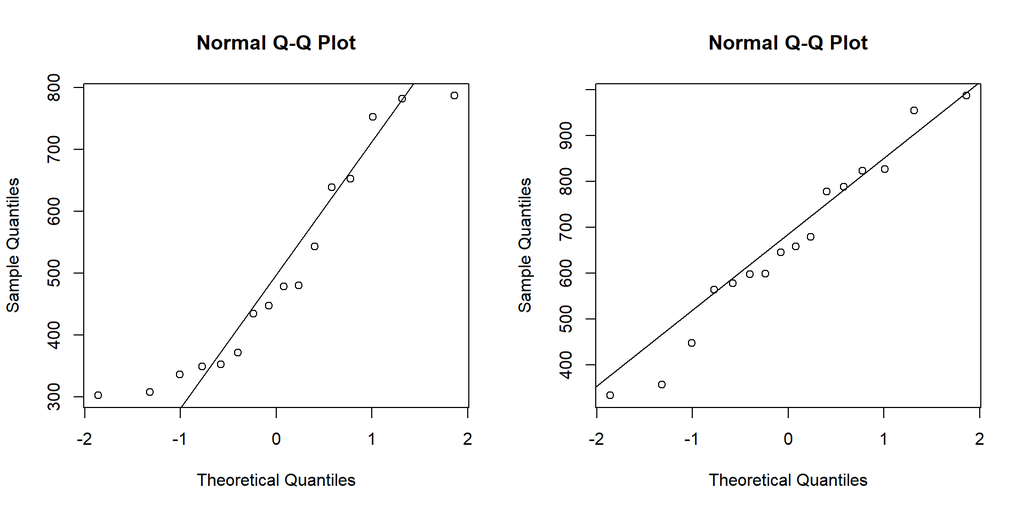

```r
# SR_INP
qqnorm(mydata[mydata$Group == 'SR_INP', ]$RT)
qqline(mydata[mydata$Group == 'SR_INP', ]$RT)

# OR_INP
qqnorm(mydata[mydata$Group == 'OR_INP', ]$RT)
qqline(mydata[mydata$Group == 'OR_INP', ]$RT)
```

```r
# Conducting Shapiro-Wilk test on all groups
aggregate(RT ~ Group, data = mydata, function(x) shapiro.test(x)$p.value)
```

```
##    Group         RT
## 1 OR_ANP 0.04878843
## 2 OR_INP 0.78201004
## 3 SR_ANP 0.93644370
## 4 SR_INP 0.05377226
```

It seems that the p-value of group OR_ANP (0.04878843) is < 0.05. This means that we have reason to believe that the data for this group may not be normally distributed. The values of the others groups are all >= 0.05, meaning they are probably normally distributed.

# 5 Variance

```r
leveneTest(RT ~ Group, data = mydata)
```

```
## Levene's Test for Homogeneity of Variance (center = median)
##       Df F value Pr(>F)
## group  3  0.6366 0.5944
##       60
```

# 6 1-way ANOVA

```r
mydata.aov <- aov(RT ~ Group, data = mydata)
summary(mydata.aov)
```

```
##             Df  Sum Sq Mean Sq F value Pr(>F)
## Group        3  237369   79123   2.081  0.112
## Residuals   60 2281409   38023
```

P-value is 0.112, which is >= 0.05. Since the p-value is >= than the α-level, the result is not significant. Therefore we should accept the null hypothesis. We can conclude that no pair of groups have different means.

# 7 Repeated Measures ANOVA

```r
library(ez)
mydata.aov <- ezANOVA(data = mydata, dv = RT, wid = Subj, within = Group,
                      detailed = TRUE, type = 3)
mydata.aov$ANOVA
```

```
##        Effect DFn DFd        SSn       SSd          F            p p<.05
## 1 (Intercept)   1  15 22104102.2 1306409.8 253.795973 8.272671e-11     *
## 2       Group   3  45   237368.9  974999.1   3.651832 1.933615e-02     *
##          ges
## 1 0.90644408
## 2 0.09423971
```

# 8 Difference between the two ANOVAs tests

The F-value is higher for the repeated measures ANOVA test in comparison to the 1-way ANOVA test. This is because we are now conducting a paired experiment (repeated measures) which makes the residuals smaller and thus the F-value higher. This then gives a higher chance for a significant result.

# 9 Sphericity

```r
mydata.aov$`Mauchly's Test for Sphericity`
```

```
##   Effect         W         p p<.05
## 2  Group 0.8849993 0.8921161
```

P-value is >= 0.05, meaning that null hypothesis is accepted for this test. This means that the assumption for sphericity is met, so we can assume homogeneity of variances of pairwise differences between levels of sentence types.

# 10 Effect size

```r
mydata.aov$ANOVA$ges[2]
```

```
## [1] 0.09423971
```

The effect size is 0.09423971.